# hw03-YumaKawai.Rmd

YumaKawai

Wednesday, October 22, 2014

### 1.階乗を計算する関数の作成

n(非負整数)の階乗はn!と表され数式で表現すると、以下のようになる。 $n!=n(n-1)(n-2)・・1,$ $0!=1$

```r
k_fctrl <- function(n = NULL){　# k_fctrlという名前で階乗を計算する関数を作る。
  ## 引数=n
  ## 返り値=x
    if(n == 0){         # nが0のとき
        return(1)
    } else if (n < 0){  # nが負の時
        return(NA)
    } else if (n > 0){  # nが正の時
        x <- n               # nにループの中で初めの値として保つためにxに代入
        while(n > 1){
            x <- x * (n - 1) # 引数として与えられた数nを(n-1)でかける
            n <- n - 1       # 次のループに(n-1)した数を渡す
        }
        return(x)
    }
}
```

### 2.自分で作った関数(k_fctrl)を使って組み合わせを計算する関数の作成

$n$個から$k$個選ぶ組み合わせは数式で表すと以下のようになる ${n \choose m}=\frac{n!}{k!(n-k)!}$

これを元に、先ほど作成した階乗の関数(k_fctrl)を用いて組み合わせを計算するための関数を作成するためのコードは以下のようになる。

```r
k_chs <- function(n = NULL, k = NULL){  # k_chsという名前で組み合わせの数を計算する関数を作成
  output <- k_fctrl(n) / (k_fctrl(k) * k_fctrl(n-k))　# 1で作った関数を数式に当てはめる
　## 引数=n(全体の数)
　##      k(選ぶ数)
　## 返り値=output
　return(output)
}
```

### 3.自分で作った関数(k_chs)を使って、二項分布の確率質量を求める関数を作成

二項分布の確率質量関数 $f(x)$ は $f(x)={n \choose x}p^x(1-p)^{n-x}$ $x=(0,1,2,3・・n)$ であり、ここで$n$はベルヌーイ試行の回数、$p$は１回のベルヌーイ試行における成功確率である。

これを元に二項分布の確率質量を求める関数を作成するコードは以下のようになる。

```r
k_dbin <- function(x = NULL, size = NULL, prob = NULL){
    ## 引数=x(パラメータ)
    ## size=試行回数
  　## prob=成功確率
  　## 返り値=output(確率質量関数)
    output <- rep(NA, length(x)) #結果を保存するベクトル
    for(i in 1:length(x)){　## 公式を元にi番目のベクトルに計算結果を代入
        output[i] <- k_chs(n = size, k = x[i]) * (prob^x[i]) * (1 - prob)^(size - x[i])
    }
    output <- ifelse(test = is.na(output), yes = 0, no = output) # NAがあれば、0に置換
    return(output)
}
```

#### 異なる$n$について計算する関数を作成する。

はじめに、複数の確率についてシミュレーションを行う関数を作成する。この関数では引数として与えられた確率`p.vec`を元に、それぞれのpにおける確率質量を計算する。返り値は行列で返され、最初の列には、二項係数${n \choose x}$の$n$から$x$の数を代入している。

```r
k_denbin <- function(n = NULL, p.vec = NULL){
    ## 引　数=n  (nのベクトル（0～nまでシミュする）)
    ## p.vec = 成功確率（ベクトルとして複数与える）
    ## 返り値:=output (確率質量関数の行列（最後列は代入されたkの数）)

    # 結果を保存する行列を用意
    output <- matrix(data = NA, nrow = length(0:n), ncol = (length(p.vec)) + 1)
    output[, 1] <- c(0:n)
    for(i in 1:length(p.vec)){
        # 関数を利用してoutputのi+1番目の列を計算する
        output[,i+1] <- k_dbin(x = c(0:n), size = n, prob = p.vec[i])
    }
    return(output)
}
```

この関数を利用して、異なるpについて計算を行う。

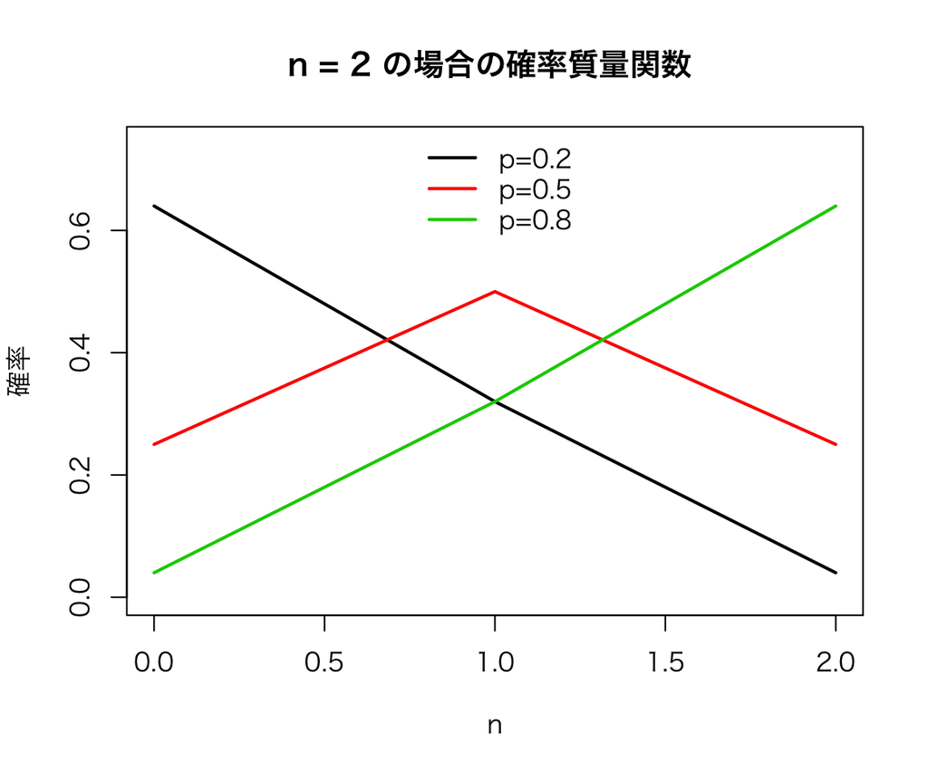

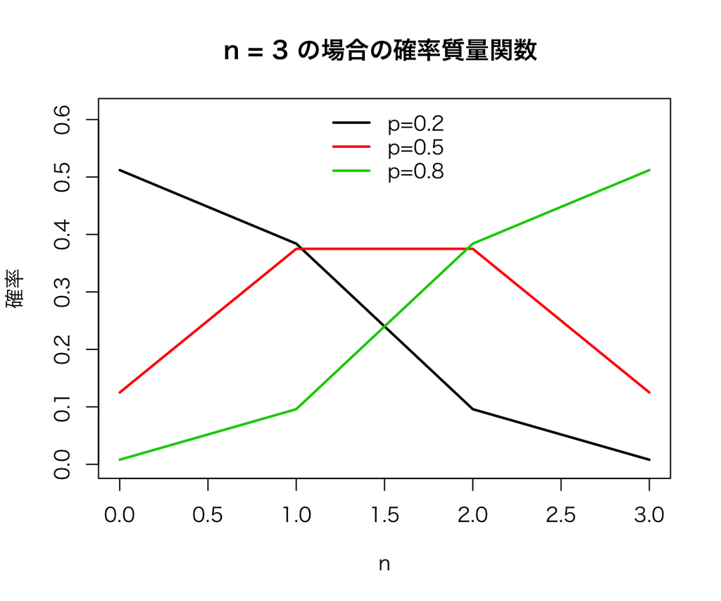

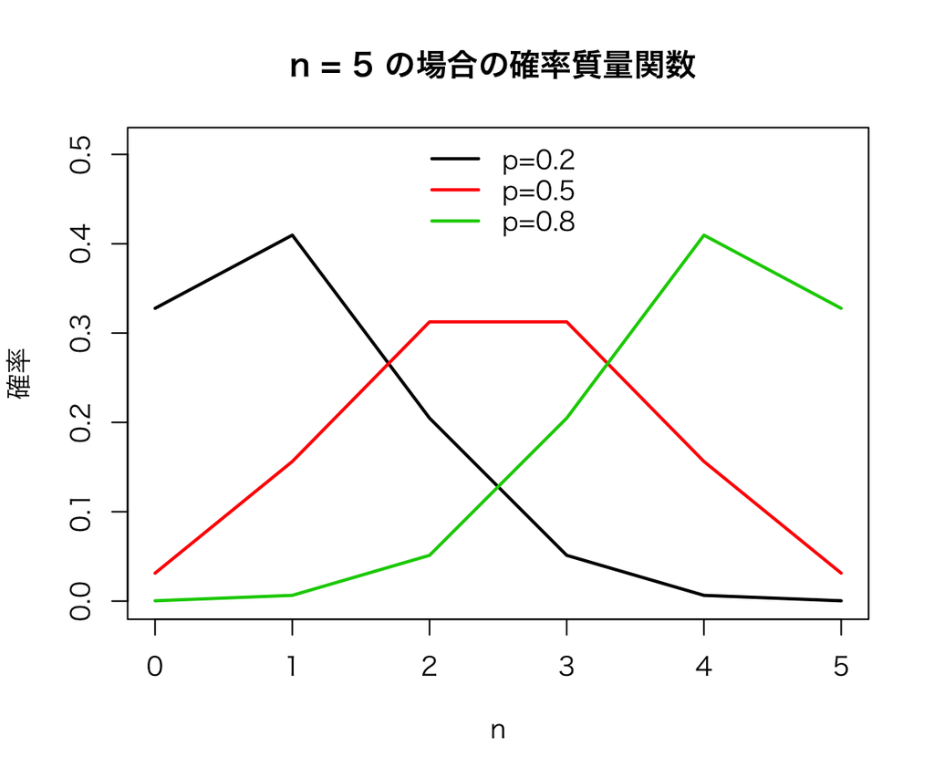

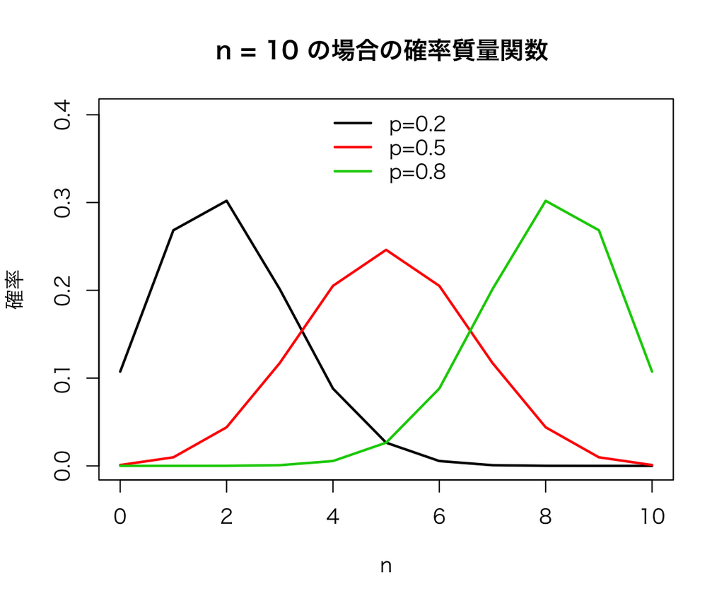

```r
# nのベクトル
n_array <- c(2, 3, 5, 10)

# pのベクトル
p_array <- c(0.2, 0.5, 0.8)

for(i in n_array){
    # 0:i（0:n）までの確率p.vecの確率質量関数を行列で出す
    k_res <- k_denbin(n = i, p.vec = p_array)

    plot(x = k_res[, 1], # xの値
         y = k_res[, 2], # 最初に与えられた成功確率における確率質量の値
         type = "l", # 折れ線グラフ
         xlab = "n", ylab = "確率",
         main = paste("n =", i, "の場合の確率質量関数", seq = ""),
         # 凡例を書くために、上を少し空ける
         xlim = c(0, max(k_res[, 1])), ylim = c(0, max(k_res[, 2:ncol(k_res)])+0.1),
         lwd = 2, col = 1)
    # 確率0.5の時の場合を図示
    lines(x = k_res[, 1], k_res[,3], type = "l", lwd = 2, col = 2)
    # 確率0.8の時の場合を図示
    lines(x = k_res[, 1], k_res[,4], type = "l", lwd = 2, col = 3)
    legend("top", legend = c("p=0.2","p=0.5", "p=0.8"), bty = "n",
       col = c(1, 2, 3), lwd = 2)
}
```